# Construcción de mapas de pronóstico para la configuración de parámetros de riesgo en cultivos de palma de aceite - Informe de Vigilancia Tecnológica e Inteligencia (VTI) 1

Informe elaborado por: Luis Miguel Aristizábal Gómez, Vanessa López, Sebastián Castro.

## Título del estudio: Determinación de la calidad del fruto de palma de aceite por medio de la medición de madurez no invasiva

| Item | Valor |
| --- | --- |
| Área interesada o solicitante | UPB - Universidad EIA - Unipalma de los llanos S.A. - Universidad de De Montfort |
| Fecha de inicio | 24/08/2021 |
| Fecha de reporte | 01/10/2021 |

## Objetivo

*Identificar principios, métodos y técnicas de determinación de la calidad del fruto de palma de aceite*

## Justificación

Este estudio está enmarcado en el proyecto "Construcción de mapas de pronóstico para la configuración de parámetros de riesgo en cultivos de palma de aceite", y contribuye al cumplimiento del objetivo específico "Desarrollar un sensor pasivo inductivo para determinar el punto optimo de cosecha de racimos de fruta fresca para el mejoramiento del proceso de producción"

## Contexto

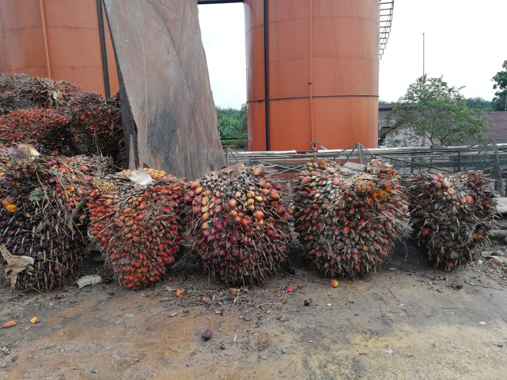

## Factores clave de vigilancia

Este estudio busca responder las siguientes preguntas:

- ¿cómo medir el nivel de madurez de un fruto cualquiera?
- ¿qué desarrollos se han hecho para medir la madurez de frutos?

El alcance de la búsqueda en una primera iteración es netamente académico, con intención de ampliarlo a búsqueda comercial y patentes en futuras iteraciones.

## Resultados esperados

El resultado final de este ejercicio es una lista de artículos relevantes para el proceso de desarrollo de un sensor que permita determinar el punto óptimo de cosecha de racimos de fruta fresca de palma de aceite. Adicionalmente, se busca identificar palabras clave no consideradas en la búsqueda inicial para nutrir futuras iteraciones.

## Lista de palabras clave

```python
import pandas as pd

keywordsDf = pd.read_excel(open("PlaneacionBusqueda_MedicionMadurez.xlsx", 'rb'),
                          sheet_name='Palabras Clave',
                          index_col=None,
                          skiprows=8,
                          usecols=range(1,5),
                          keep_default_na=False,
                         )
keywordsDf.dropna(how='all', axis=1, inplace=True)
keywordsDf.dropna(how='all', axis=0, inplace=True)
keywordsDf
```

|  | Elemento estructural 1 | Elemento estructural 2 | Elemento estructural 3 | Elemento estructural 4 |
| --- | --- | --- | --- | --- |
| 0 | "fruit ripeness" | sensor | "Hardware development" | "intelligent algorithm" |
| 1 | "oil palm ripeness" | measurement | Design | "artificial neural network" |
| 2 | "fruit maturity" | "inductive sensor" | Implementation | "Discriminant analysis" |
| 3 | "age of ripeness" | "air coil" | Construction | "deep learning" |
| 4 | "fruitfulness" | "resonant frequency" | Hardware | "support vector machine" |
| 5 | "oil palm" | "frequency selection" | Development | "vector machine" |
| 6 | "maturity classification" | "electrical circuit" |  | "algorithm selection" |
| 7 | "madurez de fruto" | "Sensor inductivo" |  | "Inteligencia artificial" |
| 8 | "identify ripeness" | "Frecuencia de resonancia" |  | "Análisis de datos" |
| 9 | "forecasting harvest time of oil palm" | "Image analysis" |  | "Redes neuronales" |
| 10 | "Ripeness estimation" | "characteristic frequency" |  | "Visión artificial" |
| 11 | "oil palm maturity detection" |  |  | "Artificial vision" |
| 12 |  |  |  |  |
| 13 |  |  |  |  |

De la lista anterior, sólo se tomaron los primeros 3 elementos estructurales AND:

*Elemento estructural 1*

"fruit ripeness" "oil palm ripeness" "fruit maturity" "age of ripeness" "fruitfulness" "oil palm" "maturity classification"

*Elemento estructural 2*

sensor measurement "inductive sensor" "air coil" "resonant frequency"

*Elemento estructural 3*

"Hardware development" Design Implementation Construction Hardware Development

## Construcción de la ecuación de búsqueda 1

Las palabras anteriores se usaron para construir la siguiente ecuación de búsqueda para SCOPUS (generada automáticamente con funciones de Python y el módulo Pandas:

> TITLE-ABS-KEY("fruit ripeness" OR "oil palm ripeness" OR "fruit maturity" OR "age of ripeness" OR "fruitfulness" OR "oil palm" OR "maturity classification") AND TITLE-ABS-KEY(sensor OR measurement OR "inductive sensor" OR "air coil" OR "resonant frequency") AND PUBYEAR > 2001

Luego, haciendo uso de los filtros en SCOPUS por áreas, se agregaron las siguientes limitaciones:

> > TITLE-ABS-KEY ( "fruit ripeness" OR "oil palm ripeness" OR "fruit maturity" OR "age of ripeness" OR "fruitfulness" OR "oil palm" OR "maturity classification" ) AND TITLE-ABS-KEY ( sensor OR measurement OR "inductive sensor" OR "air coil" OR "resonant frequency" ) AND PUBYEAR > 2001 AND ( LIMIT-TO ( SUBJAREA , "AGRI" ) OR LIMIT-TO ( SUBJAREA , "ENGI" ) OR LIMIT-TO ( SUBJAREA , "ENVI" ) OR LIMIT-TO ( SUBJAREA , "COMP" ) OR LIMIT-TO ( SUBJAREA , "MATE" ) OR LIMIT-TO ( SUBJAREA , "PHYS" ) OR LIMIT-TO ( SUBJAREA , "EART" ) OR EXCLUDE ( SUBJAREA , "SOCI" ) OR EXCLUDE ( SUBJAREA , "MEDI" ) OR EXCLUDE ( SUBJAREA , "IMMU" ) OR EXCLUDE ( SUBJAREA , "BUSI" ) OR EXCLUDE ( SUBJAREA , "DECI" ) OR EXCLUDE ( SUBJAREA , "PHAR" ) OR EXCLUDE ( SUBJAREA , "ECON" ) OR EXCLUDE ( SUBJAREA , "NEUR" ) OR EXCLUDE ( SUBJAREA , "NURS" ) OR EXCLUDE ( SUBJAREA , "ARTS" ) OR EXCLUDE ( SUBJAREA , "VETE" ) )

### Filtrado de resultados

Se obtuvieron **778 resultados obtenidos**. Para reducir el número de resultados:

1. se ordenó por relevancia
2. se descargó la información principal de los primeros 100.
3. se realiza un filtrado manual por título y tema de los documentos.

Finalmente, se obtienen **53 resultados**, los cuales se consolidan en un archivo de Excel.

## Construcción de la ecuación de búsqueda 2

Las palabras anteriores se usaron para construir la siguiente ecuación de búsqueda para SCOPUS (generada automáticamente con funciones de Python y el módulo Pandas:

> TITLE-ABS-KEY("fruit ripeness" OR "oil palm ripeness" OR "fruit maturity" OR "age of ripeness" OR "fruitfulness" OR "oil palm" OR "maturity classification") AND TITLE-ABS-KEY(sensor OR measurement OR "inductive sensor" OR "air coil" OR "resonant frequency") AND TITLE-ABS-KEY("Hardware development" OR Design OR Implementation OR Construction OR Hardware OR Development) AND PUBYEAR > 2001

Luego, haciendo uso de los filtros en SCOPUS por áreas, se agregaron las siguientes limitaciones:

> TITLE-ABS-KEY ( "fruit ripeness" OR "oil palm ripeness" OR "fruit maturity" OR "age of ripeness" OR "fruitfulness" OR "oil palm" OR "maturity classification" ) AND TITLE-ABS-KEY ( sensor OR measurement OR "inductive sensor" OR "air coil" OR "resonant frequency" ) AND TITLE-ABS-KEY ( "Hardware development" OR design OR implementation OR construction OR hardware OR development ) AND PUBYEAR > 2001 AND ( LIMIT-TO ( SUBJAREA , "AGRI" ) OR LIMIT-TO ( SUBJAREA , "ENGI" ) OR LIMIT-TO ( SUBJAREA , "COMP" ) OR LIMIT-TO ( SUBJAREA , "ENVI" ) OR LIMIT-TO ( SUBJAREA , "PHYS" ) OR LIMIT-TO ( SUBJAREA , "MATE" ) ) AND ( EXCLUDE ( SUBJAREA , "EART" ) )

### Filtrado de resultados

Se obtuvieron **217 resultados obtenidos**. Para reducir el número de resultados:

1. se descargó la información principal de todos los artículos.
2. se realiza una comparación y remoción de duplicados con la búsqueda anterior.
3. se realiza un filtrado manual por título y tema de los documentos.

Finalmente, se obtienen **38 resultados**, los cuales se consolidan en el mismo archivo de Excel.

"C:\Users\LMAG\Universidad EIA\Proyecto Unipalma 2021 - General\00_VigilanciaInteligencia\busquedas\6_Filtro de documentos por titulo.xlsx"

## Consolidado de búsquedas

```python
mainDf = pd.read_excel(open("./busquedas/6_Filtro de documentos por titulo.xlsx", 'rb'),
                          sheet_name='Busqueda filtrada',
                          index_col=None,
#                           skiprows=8,
#                           usecols=range(1,5),
                          keep_default_na=False,
                         )
mainDf.dropna(how='all', axis=1, inplace=True)
mainDf.dropna(how='all', axis=0, inplace=True)
mainDf
```

|  | AUTOR | TITULO | LEER ABSTRACT | DESCARGAR | AÑO | Nombre Publicación | LINK | DOI | ABSTRACT |
| --- | --- | --- | --- | --- | --- | --- | --- | --- | --- |
| 0 | Sinambela R., Mandang T., Subrata I.D.M., Herm... | Application of an inductive sensor system for ... | SÍ |  | 2020 |  | https://www.scopus.com/inward/record.uri?eid=2... |  | Ripeness estimation of oil palm fresh fruit bu... |
| 1 | Misron N., Aliteh N.A., Harun N.H., Tashiro K.... | Relative estimation of water content for flat-... | SÍ |  | 2017 |  | https://www.scopus.com/inward/record.uri?eid=2... |  | The paper aims to study the sensor that identi... |
| 2 | Misron N., Harun N.H., Lee Y.K., Sidek R.M., A... | Improvement in sensitivity of an inductive oil... | SÍ |  | 2014 |  | https://www.scopus.com/inward/record.uri?eid=2... |  | Among palm oil millers, the ripeness of oil pa... |
| 3 | Aliteh N.A., Misron N., Aris I., Sidek R.M., T... | Triple flat-type inductive-based oil palm frui... | SÍ |  | 2018 |  | https://www.scopus.com/inward/record.uri?eid=2... |  | This paper aims to study a triple flat-type ai... |
| 4 | Harun N.H., Misron N., Sidek R.M., Aris I., Ah... | Investigations on a novel inductive concept fr... | SÍ |  | 2013 |  | https://www.scopus.com/inward/record.uri?eid=2... |  | From the Malaysian harvester's perspective, th... |
| ... | ... | ... | ... | ... | ... | ... | ... | ... | ... |
| 86 | Vanoli M., Zerbini P.E., Rizzolo A., Torricell... | Time-resolved Reflectance Spectroscopy for the... | NO |  | 2010 | Acta Horticulturae | https://www.scopus.com/inward/record.uri?eid=2... | 10.17660/ActaHortic.2010.877.189 |  |
| 87 | Srivastava S., Vani B., Sadistap S. | Handheld, smartphone based spectrometer for ra... | NO |  | 2021 | Journal of Food Measurement and Characterization | https://www.scopus.com/inward/record.uri?eid=2... | 10.1007/s11694-020-00693-w |  |
| 88 | Abdellahhalimi, Roukhe A., Abdenabi B., El Bar... | Sorting dates fruit bunches based on their mat... | SÍ |  | 2013 | Journal of Theoretical and Applied Information... | https://www.scopus.com/inward/record.uri?eid=2... |  |  |
| 89 | Gao Z., Pang G., Li L., Zhao K., Wang X., Ji C. | Design of hand-operated piggyback jaw gripper ... | NO |  | 2019 | Nongye Gongcheng Xuebao/Transactions of the Ch... | https://www.scopus.com/inward/record.uri?eid=2... | 10.11975/j.issn.1002-6819.2019.01.005 |  |
| 90 | Long Y., Lian Y., Ma M., Song H., He D. | Detection of tomato hardness based on hyperspe... | NO |  | 2019 | Nongye Gongcheng Xuebao/Transactions of the Ch... | https://www.scopus.com/inward/record.uri?eid=2... | 10.11975/j.issn.1002-6819.2019.13.032 |  |

91 rows × 9 columns

## Selección de los artículos según título

De los anteriores resultados, se filtra nuevamente con base en el título, tratando de responder estas preguntas:

- ¿habla de técnicas de medición de madurez de alguna fruta?
- ¿habla de desarrollo de algún sensor o hardware?
- ¿habla sobre medición de madurez de la fruta de palma de aceite?

Si alguna de las preguntas tiene como respuesta SÍ, se marca para lectura de abstract.

Esta lista de documentos se considerará como el entregable principal de este ejercicio. Se verificará que se cuente con toda la información necesaria sobre los documentos, incluyendo palabras claves, abstract e información de publicación.

```python
sensoresDf = pd.read_excel(open("./busquedas/6_Filtro de documentos por titulo.xlsx", 'rb'),
                          sheet_name='Tipos de sensores',
                          index_col=None,
#                           skiprows=8,
#                           usecols=range(1,5),
                          keep_default_na=False,
                         )
sensoresDf.dropna(how='all', axis=1, inplace=True)
sensoresDf.dropna(how='all', axis=0, inplace=True)
tecnicasDf = pd.read_excel(open("./busquedas/6_Filtro de documentos por titulo.xlsx", 'rb'),
                          sheet_name='Técnicas de medición de madurez',
                          index_col=None,
#                           skiprows=8,
#                           usecols=range(1,5),
                          keep_default_na=False,
                         )
tecnicasDf.dropna(how='all', axis=1, inplace=True)
tecnicasDf.dropna(how='all', axis=0, inplace=True)
sensoresDf = sensoresDf.sort_values("AÑO",ascending =  False)
tecnicasDf = tecnicasDf.sort_values("AÑO",ascending =  False)
```

## Selección de los artículos según abstract

Según el abstract, clasificar los artículos de acuerdo a los temas (preguntas anteriores):

1. Técnicas de medición de madurez de frutas.
2. Desarrollo de sensores/hardware.
3. Medición de la calidad del fruto de palma de aceite (esta termina siendo una subcategoría de la 1 por lo cual no se tuvo en cuenta).

Aquellos que se identifiquen como muy relacionados, se marcan para descarga.

### Resultado:

1. Técnicas de medición: **20 artículos para descargar**
2. Desarrollo de sensores: **25 artículos para descargar**

En el archivo **"6_Filtro de documentos por titulo.xlsx"** se puede encontrar conceptos clave identificados en los resúmenes (columna *criterio selección 1*)

### Artículos sobre tipos de sensores

```python
pd.set_option('display.max_colwidth', None)
sensoresDf[["AUTOR","TITULO","AÑO","Criterio selección 1","DESCARGAR"]]
```

|  | AUTOR | TITULO | AÑO | Criterio selección 1 | DESCARGAR |
| --- | --- | --- | --- | --- | --- |
| 27 | Xuan G., Gao C., Shao Y., Wang X., Wang Y., Wang K. | Maturity determination at harvest and spatial assessment of moisture content in okra using Vis-NIR hyperspectral imaging | 2021 | Detección de madurez con base en imágenes hiper espectrales visibles y de infrarrojo para evaluar el estado de madurez y el contenido de humedad de la fruta | SÍ |
| 22 | Carvalho M., Ribeiro P., Romão V., Cardoso S. | Smart fingertip sensor for food quality control: Fruit maturity assessment with a magnetic device | 2021 | En este documento se propone un sensor de textura basado en receptores cilíndricos similares a pelos altamente sensibles, para permitir una rápida evaluación de la calidad de la fruta mas no habla de … | NO |
| 29 | Misron N., Azhar N.S.K., Hamidon M.N., Aris I., Tashiro K., Nagata H. | Effect of charging parameter on fruit battery-based oil palm maturity sensor | 2020 | Sensor de madurez basado en baterías de frutas para analizar el efecto del sensor en varios parámetros (resistencia de carga, el voltaje de carga y el tiempo de carga) | SÍ |
| 2 | Quan G.J., Shariff A.R.B.M., Nawi N.M. | Grading of maturity of oil palm fruit based on visible and NIR band | 2020 | eL artículo menciona el uso de un detector de madurez de palma aceitera llamado OPRiD, este sensor en basado en espectrometria y análisis de imágenes | SÍ |
| 6 | Abdul Aziz A.H., Abuzar S.A., Azol M.E., Che Rose N.H., Mohmad R.L. | Test Frequency Optimization Using Single Factor ANOVA for Capacitive Oil Palm Fruit Ripeness Sensor | 2020 | El documento tiene como función describir el trabajo para determinar la mejor frencuecia para la clasificación capacitiva de madurez en la fruta del aceite de palama | SÍ |
| 24 | Sinambela R., Mandang T., Subrata I.D.M., Hermawan W. | Application of an inductive sensor system for identifying ripeness and forecasting harvest time of oil palm | 2020 | El propósito de este estudio es desarrollar un dispositivo de detección de la madurez de la palma de aceite que no solo sea capaz de identificar la madurez de la palma de aceite, sino también de prede… | SÍ |
| 4 | Bhatnagar S., Gordon M., Hall C., Hernandez D., MacLean A., Picone M., Purdy T., Sim H., Tissot G., Hu A.-P. | NIR-based fruit ripeness sensor embodiments using low-cost LEDs and photodiodes | 2019 | Plantea el desarrollo de dos sensores de espectrometria para la detección de madurez de arándanos y melocotes y además el artículo describe el desarrollo, fabricación y prueba de los sensores menciona… | SÍ |
| 13 | Ahmad A.F., Abbas Z., Abrass H.A., You K.Y. | Optimum design of a microstrip ring resonator sensor to determine the moisture content in oil palm fruits and seeds | 2019 | El abtract propone el implementar un sistema de deteccion automatizado para determinar la madurez del fruto de palma de aceite mediante un resonador de anillo de microcinta y un analizador de red cont… | SÍ |
| 18 | Nnodim C.T., Fath El-Bab A.M.R., Ikua B.W., Sila D.N. | Design and simulation of a tactile sensor for fruit ripeness detection | 2019 | Este artículo tiene como objetivo presentar un procedimiento de diseño detallado para desarrollar un sensor táctil que pueda diferenciar entre diferentes niveles de madurez en la fruta de mango. El se… | SÍ |
| 1 | Aliteh N.A., Misron N., Aris I., Sidek R.M., Tashiro K., Wakiwaka H. | Triple flat-type inductive-based oil palm fruit maturity sensor | 2018 | El artículo propone estudiar un sensor inductivo de bobina de aire de tiplo "plano triple" que puede identificar dos estapas de madurez de frutos de palma aceitera, maduros e inmaduros | SÍ |
| 26 | Flores-Cortez O.O., Rosa V.I., Barrera J.O. | Determination of the level of ripeness and freshness of fruits by electronic sensors. A review [Determinación del nivel de maduracion y frescura de frutos por medio de sensores electrónicos] | 2018 | El objetivo del artúclo es diseñar una plataforma electrónica digital programable, equipada con sensores de gas y redes inalámbricas para el desarrollo de un prototipo electrónico rápido y de bajo cos… | SÍ |
| 8 | Utom S.L., Mohamad E.J., Ameran H.L.M., Kadir H.A., Muji S.Z.M., Rahim R.A., Pusppanathan J. | Non-Destructive Oil Palm Fresh Fruit Bunch (FFB) grading technique using optical sensor | 2018 | El resultado de esta investifación es estudiar y comprender el proceso de uso LED y sensor óptico como método de recopilación de datos para determinar el nivel de madurez del fruto de palma aceitera | SÍ |
| 28 | Misron N., Aliteh N.A., Harun N.H., Tashiro K., Sato T., Wakiwaka H. | Relative estimation of water content for flat-type inductive-based oil palm fruit maturity sensor | 2017 | Sensor detector de madurez de fruta de palma de aceite usando flat-type inductive basado la frecuencia de resonancia | SÍ |
| 20 | Leekul P., Chivapreecha S., Phongcharoenpanich C., Krairiksh M. | Rician k-Factors-Based Sensor for Fruit Classification by Maturity Stage | 2016 | En este trabajo se ha propuesto un sistema sensor no invasivo y no destructivo para clasificar los frutos de durian según las etapas de madurez. El diseño del sistema de sensores adoptó el principio d… | SÍ |
| 19 | Srivastava S., Sadisatp S. | Development of a low cost optimized handheld embedded odor sensing system (HE-Nose) to assess ripeness of oranges | 2016 | El artículo presenta el desarrollo un sistema de nariz electrónico integrado avanzado basado en ARM-9 (controlador S3C2440) para la adquisición de olores, el procesamiento y la predicción del nivel de… | SÍ |
| 15 | Cheng E.M., Abbas Z., AbdulMalek M., Lee K.Y., You K.Y., Khor S.F., Hassan J., Zainuddin H. | Finite difference analysis of an open-ended, coaxial sensor made of semi-rigid coaxial cable for determination of moisture in tenera oil palm fruit | 2016 | En este trabajo, se propone el uso del Método de Diferencia Finita (FDM) para determinar el coeficiente de reflexión de un sensor coaxial de extremo abierto para determinar el contenido de humedad de … | NO |
| 16 | Kinjo H., Oshiro N., Duong S.C. | Fruit maturity detection using neural network and an odor sensor: Toward a quick detection | 2015 | Este trabajo presenta un método de detección rápida de la madurez de la fruta en unos segundos de la señal ascendente del sensor de olor. Utilizando una red neuronal, el método funciona sin esperar a … | SÍ |
| 10 | Harun N.H., Misron N., Sidek R.M., Aris I., Wakiwaka H., Tashiro K. | Dual resonant frequencies effects on an induction-based oil palm fruit sensor | 2014 | Este artículo propone el diseño de un sensor de madurez de frutos de palma aceitera por medio de un sensor de un bobina de aire basado en un sensor inductivo más enfocado en el efecto del diámatro de … | SÍ |
| 9 | Kassim M.S.M., Ismail W.I.W., Teik L.H. | Oil palm fruit classifications by using near infrared images | 2014 | Se menciona la comparación de la medición de la madurez de la fruta de palma de aceite en forma destructiva y no destructiva, esta último por medio de un sensor multiespectral y usando un método NIR | SÍ |
| 0 | Misron N., Harun N.H., Lee Y.K., Sidek R.M., Aris I., Wakiwaka H., Tashiro K. | Improvement in sensitivity of an inductive oil palm fruit sensor | 2014 | El abstract menciona el uso de un sensor para detectar la madurez de los racimos de fruto de la palma aceitera y que ademas se investiga el diseño de un sensor de bobina de "aire" propuesto basado en … | SÍ |
| 17 | Hawari H.F., Saad S.M., Samsudin N.M., Md Shakaff A.Y., Wahab Y., Hashim U. | Sensory system for detection of Harumanis mango fruit maturity | 2013 | Mediante el uso de la estructura de electrodo interdigitado (IDE), se fabricó una matriz de sensores para detectar mango volátil utilizando polímero impreso molecular (MIP) como material de detección … | SÍ |
| 23 | Abdellahhalimi, Roukhe A., Abdenabi B., El Barbri N. | Sorting dates fruit bunches based on their maturity using camera sensor system | 2013 | Este artículo presenta el desarrollo y aplicación del sistema de análisis de imágenes y visión por computadora en la evaluación de la calidad y madurez de productos en el campo agrícola | SÍ |
| 3 | Saeed O.M.B., Sankaran S., Shariff A.R.M., Shafri H.Z.M., Ehsani R., Alfatni M.S., Hazir M.H.M. | Classification of oil palm fresh fruit bunches based on their maturity using portable four-band sensor system | 2012 | Mención de la clasificación de los racimos de frutas de palma aceitera mediante un sensor óptico activo portatil multibanda | SÍ |
| 14 | Yee L.K., Abbas Z., Jusoh M.A., Yeow Y.K., Meng C.E. | Determination of moisture content in oil palm fruits using a five-port reflectometer | 2011 | Este artículo presenta el desarrollo de un reflectometro de microondas para la determinación de humedad en frutos de palma aceitera mas no menciona si este serviría para la detección de madurez | NO |
| 7 | Aziz A.H.A., Ismail A.H., Ahmad R.B., Isa C.M.N.C., Farook R.S.M., Husin Z., Ezanuddin A.A.M., Shakaff A.Y.Md. | Design of a capacitive sensor for oil palm fresh fruit bunch maturity grading | 2011 | En el artículo se diseña y desarrolla un sistema de detección capacitiva con el propósito de clasificar racimos de frutas frescas de palma de aceitera | SÍ |
| 11 | Yeow Y.K., Abbas Z., Khalid K. | Application of microwave moisture sensor for determination of oil palm fruit ripeness | 2010 | Describe el diseño de un sensor de humedad para el contenido de humedad de los frutos de palma aceitera de diversos grados de madurez, sin embargo no se menciona que el sensor mida la madurez de la fr… | NO |
| 21 | Fito P., Castro-Giráldez M., Fito P.J., Chenoll C. | Development of a dielectric spectroscopy technique for the determination of apple (Granny Smith) maturity | 2010 | Este artículo propone medicioens dieléctrias de la manzada durante su madurez con el fin de encontrar relaciones con los compuestos fisiologicos de la manza, el resultado indica que se encontraron bue… | SÍ |
| 25 | Yeow Y.K., Abbas Z., Atan K.A.M., Long N.M.A.N., Hassan J., Shaari A.H. | Finite element analysis for oil palm fruit using open-ended coaxial sensor | 2008 | Este artículo presenta una nueva técnica para predecir el coeficiente de reflexión de un sensor de microondas para frutos de palma aceitera utilizando el método de elementos finitos (FEM). Lo cual no … | NO |
| 5 | Wang L.-Y., Zhang D.-X., Zhang H.-J., Wang X.-P. | Measurement of fruit maturity based on laser-induced photoluminescence spectrum | 2008 | El artículo propone un sensor de madurez mediante el uso de un láser semiconductor el cual según el abstract es de bajo costo y además es concebible probar la madurez de una fruta de manera convenient… | SÍ |
| 12 | Khalid K., Ghretli M.M., Abbas Z., Grozescu I.V. | Development of planar microwave moisture sensors for hevea rubber latex and oil palm fruits | 2006 | Se describe una revisión de varios sensores de humedad que utilizan estructuras planas según el abstract este sensor podrá ser utilzado para medir la madurez de la fruta de aceite o el contenido de ac… | SÍ |

### Artículos sobre técnicas de medición de madurez

```python
tecnicasDf[["AUTOR","TITULO","AÑO","Criterio selección 1","DESCARGAR"]]
```

|  | AUTOR | TITULO | AÑO | Criterio selección 1 | DESCARGAR |
| --- | --- | --- | --- | --- | --- |
| 0 | Adedayo O., Onibonoje M., Isa M. | A layer-sensitivity based artificial neural network for characterization of oil palm fruitlets | 2021 | Red neuronal para la predicción de madurez con sensores coaxiales de microondas de laboratorio dentro de 2-4 GHz | NO |
| 1 | Brucal S.G.E., Colobong J.B., De Guzman D.B., De Leon J.N.M., Samaniego L.A., Yong E.D. | Papaya maturity classification in MATLAB platform using lab method and DHT11 sensor | 2021 | Detección de madurez por medio de procesamiento de imagenes en color de una papaya en MATLAB (Clustering Based Techniques and LAB Method) | SÍ |
| 2 | You K.Y., Wee F.H., Lee Y.S., Abbas Z., Lee K.Y., Cheng E.M., Khe C.S., Jamlos M.F. | A Review of Oil Palm Fruit Ripeness Monitoring Using Microwave Techniques in Malaysia | 2020 | Comparación de sensores de microonda y métodos de monitoreo ópticos | SÍ |
| 3 | Fadchar N.A., Cruz J.C.D. | A Non-Destructive Approach of Young Coconut Maturity Detection using Acoustic Vibration and Neural Network | 2020 | Detección de madurez de coco por respuestas acusticas en un sensor de vibración | SÍ |
| 4 | Altaf S., Ahmad S., Zaindin M., Soomro M.W. | Xbee-based wsn architecture for monitoring of banana ripening process using knowledge-level artificial intelligent technique | 2020 | Red de nodos de sensores inalambricos con Xbee | NO |
| 5 | Delina N.K., Ayub Wahab I.H., Khairan A. | The Measurement of Maturity Level in Chili's Using Index Pixel | 2020 | Detección de madurez por medio de toma de imágenes clasificado por píxeles de indice | SÍ |
| 6 | Baek S., Lim J., Lee J.G., McCarthy M.J., Kim S.M. | Investigation of the maturity changes of cherry tomato using magnetic resonance imaging | 2020 | Deteccion de madurez por medio de imágenes de resonancia magnética | SÍ |
| 7 | Mavi M.F., Husin Z., Badlishah Ahmad R., Yacob Y.M., Farook R.S.M., Tan W.K. | Mango ripeness classification system using hybrid technique | 2019 | Detección de madurez por medio de método híbrido de procesamiento de imágenes y detección de olores | SÍ |
| 8 | Ahmad K.A.B., Othman M., Syed Abdullah S.L., Rasidah Ali N., Muhamat Dawam S.R. | Mango Shape Maturity Classification Using Image Processing | 2019 | Detección de madurez de mangos por medio de procesamiento de imágenes y forma del fruto en visión computacional | SÍ |
| 9 | Surya Kiran M., Niranjana G. | A research on fruit maturity detection techniques | 2019 | Encuesta de detección de madurezas de frutas existentes. | SÍ |
| 10 | Gutiérrez S., Wendel A., Underwood J. | Spectral filter design based on in-field hyperspectral imaging and machine learning for mango ripeness estimation | 2019 | Selección de filtros ópticos para diseñar un multi-spectral sensing system de bajo costo | SÍ |
| 13 | Tu S., Xue Y., Zheng C., Qi Y., Wan H., Mao L. | Detection of passion fruits and maturity classification using Red-Green-Blue Depth images | 2018 | Detección de madurez por medio de un sensor cinético y procesamiento de imágenes | SÍ |
| 12 | Alfatni M.S.M., Mohamed Shariff A.R., Bejo S.K., Ben Saaed O.M., Mustapha A. | Real-time oil palm FFB ripeness grading system based on ANN, KNN and SVM classifiers | 2018 | Clasificación de madurez en tiempo real basado en clasificadores ANN, KNN y SVM con características externas de la fruta | SÍ |
| 11 | Tan S., Zhang L., Yang J. | Sensing fruit ripeness using wireless signals | 2018 | Detector de madurez por medio de señales WiFi con los cambios fisiológicos y mide la similitud entre las características extraídas y las de los perfiles de madurez para identificar el nivel de madurez… | SÍ |
| 14 | Iswari N.M.S., Wella, Ranny | Fruitylicious: Mobile application for fruit ripeness determination based on fruit image | 2017 | Relación entre la imagen digital de la fruta y el nivel de dulzura con un refractómetro usando el método del vecino k mas cercano | SÍ |
| 15 | Sakurai N., Terasaki S., Akimoto H. | Non-destructive determination of fruit maturity by a resonant vibration technique | 2016 | Frecuencias de resonancias relacionado con la madurez y toman un modulo de elasticidad para predecir los dias faltantes para la madurez total | SÍ |
| 16 | Hasanuddin N.H., Wahid M.H.A., Shahimin M.M., Hambali N.A.M.A., Nazir N.S., Khairuddin N.Z., Ramli M.M., Isa S.S.M. | Design and Development of ZnO Based Gas Sensor for Fruit Ripening Detection | 2016 | Detección de madurez por medio de oxido de zinc y piezoelectrico | NO |
| 17 | Diana Carolina C.P., Deivis David N.T. | Classification of oranges by maturity, using image processing techniques | 2014 | Detección de madurez por medio de camaras con filtros de luz y sombra y en el entorno MATLAB determinan la madurez de una naranja | SÍ |
| 18 | Harun N.H., Misron N., Sidek R.M., Aris I., Ahmad D., Wakiwaka H., Tashiro K. | Investigations on a novel inductive concept frequency technique for the grading of oil palm fresh fruit bunches | 2013 | Sensor detecta madurez por resonancia e inductancia de las bobinas, clasificandolo por maduro o inmaduro | SÍ |
| 19 | Hazir M.H.M., Shariff A.R.M., Amiruddin M.D., Ramli A.R., Iqbal Saripan M. | Oil palm bunch ripeness classification using fluorescence technique | 2012 | Sensor de fluorecencia envia una luz ultravioleta escaneando 10 veces cada racimo y determina poco madura, madura y muy madura (90% precisión) | SÍ |
| 20 | Keshvadi A., Endan J.B., Harun H., Ahmad D., Saleena F. | The reflection of moisture content on palm oil development during the ripening process of fresh fruits | 2012 | Relación entre humedad, desarrollo de la semilla durante el proceso de maduración de fruto de palma de aceite | NO |
| 21 | Shaarani S.M., Cárdenas-Blanco A., Amin M.G., Soon N.G., Hall L.D. | Monitoring development and ripeness of oil palm fruit (Elaeis guneensis) by MRI and bulk NMR | 2010 | Rastrear desarrollo de la fruta de palma por medio de imágenes por resonancia magnética y ¿resonancia magnética nuclear a granel? | NO |
| 22 | Benedetti S., Buratti S., Mannino S. | Detecting of fruit ripeness in the orchard, packing house and retail store of the future | 2009 | Nariz electronica basa en sensor quimico y se clasifican como poco maduro, maduro yb muy maduro. | SÍ |
| 23 | Zulhusin, Aziz A.H.A., Ahmad R.B. | Feasibility study of a non-destructive fruit maturity testing system on banana utilizing capacitive properties | 2008 | Metodos de detección de madurez por medio de un sensor capacitivo | SÍ |
| 24 | Geyer M., Herold B., Zude M., Truppel I. | Non-destructive evaluation of apple fruit maturity on the tree | 2007 | Evaluación de la madurez de una fruta por medio de un espectrometro por medio de clorofila y antocianinas | SÍ |

## Descarga y estudio de los artículos

La información de estos artículos debe ayudar a responder las siguientes preguntas *(lista en construcción)*

1. *¿cuáles son las principales técnicas usadas para determinar el punto optimo de cosecha de racimos de fruta fresca para el mejoramiento del proceso de producción de palma de aceite?*
2. *¿cuáles son las ventajas y desventajas de una técnica con respecto a otra?*
3. *¿Los sensores pasivo inductivos presentan ventajas considerables respecto a los otros tipos de sensores?*

Esta lista de preguntas está abierta, si tiene sugerencias o correcciones, puede escribir a este correo

## Conformación de la base de datos

Aquí debemos tomar decisiones sobre cuál gestor de bibliografías nos conviene más a nivel de proyecto.

Opciones:

- Archivo .bib (bibtex) gestionado en JabRef
- Archivo .csv gestionado en excel
- Base de datos gestionada en la nube por Mendeley
- otros...

*Esta discusión está abierta a la fecha de redacción (2021/10/08)*

## Extra: generación de reporte interactivo

```python
#Importing the function
from pandas_profiling import ProfileReport
```

```python
mergeDf = pd.concat([tecnicasDf,sensoresDf])

profile = ProfileReport(mergeDf, title='Artículos seleccionados por título', explorative = True)
profile
```

[interactive chart not shown]